# Report for Uniprot-Identified Tissue-Specific Proteins

Angela Yoder

2021-10-12

**The goals of this program are:**

1. Summarize the genes identified as tissue-specific by uniprot
1. Look at the criteria for tissue-specificity within uniprot
2. Run Ssec code with these genes
1. Uniprot-identified Tissue-Specific and exclusive to the tissues
2. Uniprot-identified Tissue-Specific, without excluding those not exclusive to the tissues
3. Determine the characteristics of those that are labeled as tissue-specific but are not exclusive to one tissue

## CHECK INF!!!

Do I want to try full dataset as target?

Below is a table of the number of genes in the labeled categories. We can see the sample size go down dramatically with the conditioning on tissue exclusivity. The first Ssec score analysis below will be using the Secreted TS Uniprot Exclusive brain and liver datasets (the last two rows below). The second Ssec score analysis will be using the Secreted TS Uniprot brain and liver datasets (the fifth and sixth rows).

Number of Genes

|  | x |
| --- | --- |
| TS Uniprot Brain | 1592 |
| TS Uniprot Liver | 1305 |
| TS Uniprot Exclusive Brain | 321 |
| TS Uniprot Exclusive Liver | 34 |
| Secreted TS Uniprot Brain | 168 |
| Secreted TS Uniprot Liver | 129 |
| Secreted TS Uniprot Exclusive Brain | 47 |
| Secreted TS Uniprot Exclusive Liver | 8 |

## Secreted TS Uniprot Exclusive

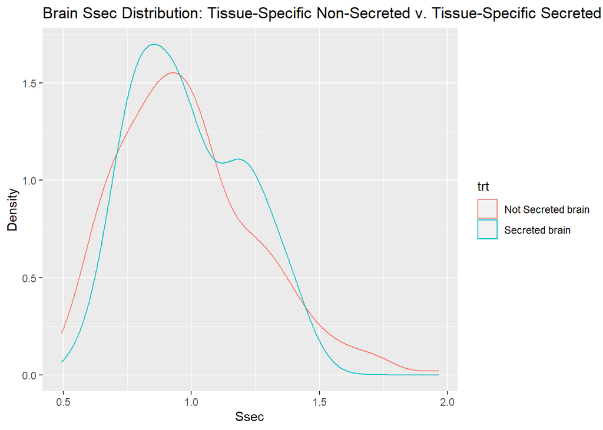

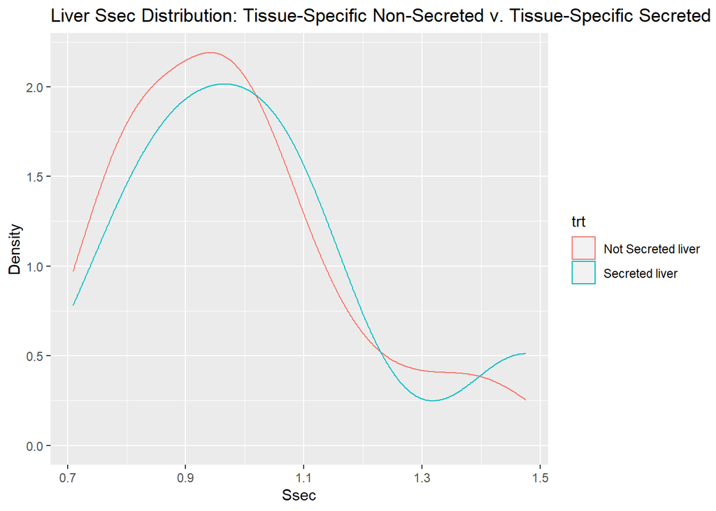

```
##
##  Asymptotic Wilcoxon-Mann-Whitney Test
##
## data:  val by trt (Not Secreted brain, Secreted brain)
## Z = -0.41338, p-value = 0.6793
## alternative hypothesis: true mu is not equal to 0
```

```
##
##  Asymptotic Wilcoxon-Mann-Whitney Test
##
## data:  val by trt (Not Secreted liver, Secreted liver)
## Z = -0.5278, p-value = 0.5976
## alternative hypothesis: true mu is not equal to 0
```

## Secreted TS Uniprot

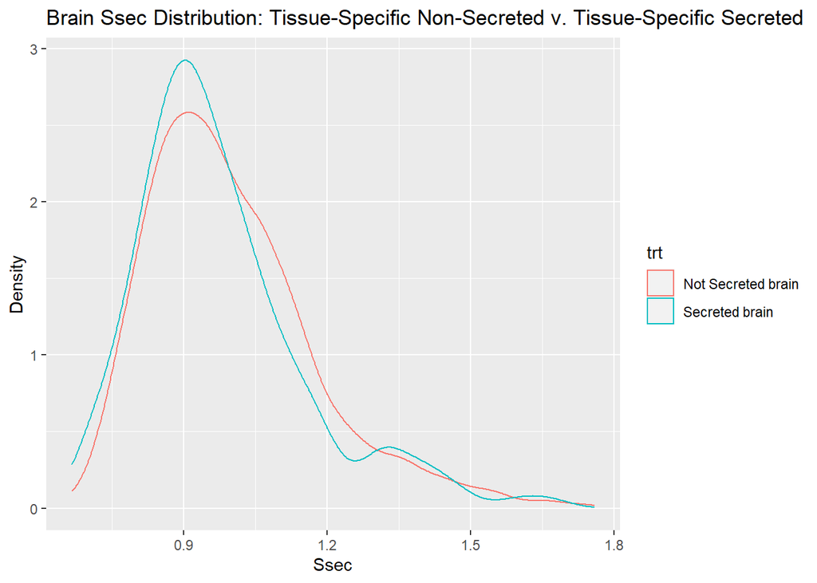

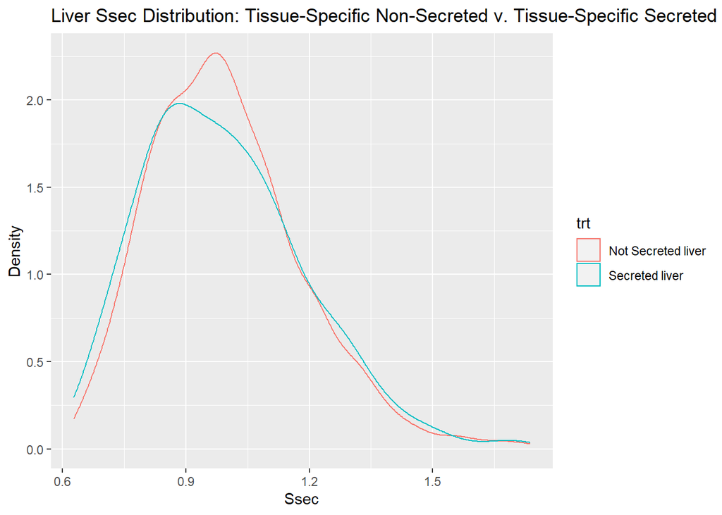

```
##
##  Asymptotic Wilcoxon-Mann-Whitney Test
##
## data:  val by trt (Not Secreted brain, Secreted brain)
## Z = 1.9024, p-value = 0.05712
## alternative hypothesis: true mu is not equal to 0
```

```
##
##  Asymptotic Wilcoxon-Mann-Whitney Test
##
## data:  val by trt (Not Secreted liver, Secreted liver)
## Z = 0.43167, p-value = 0.666
## alternative hypothesis: true mu is not equal to 0
```

## Looking

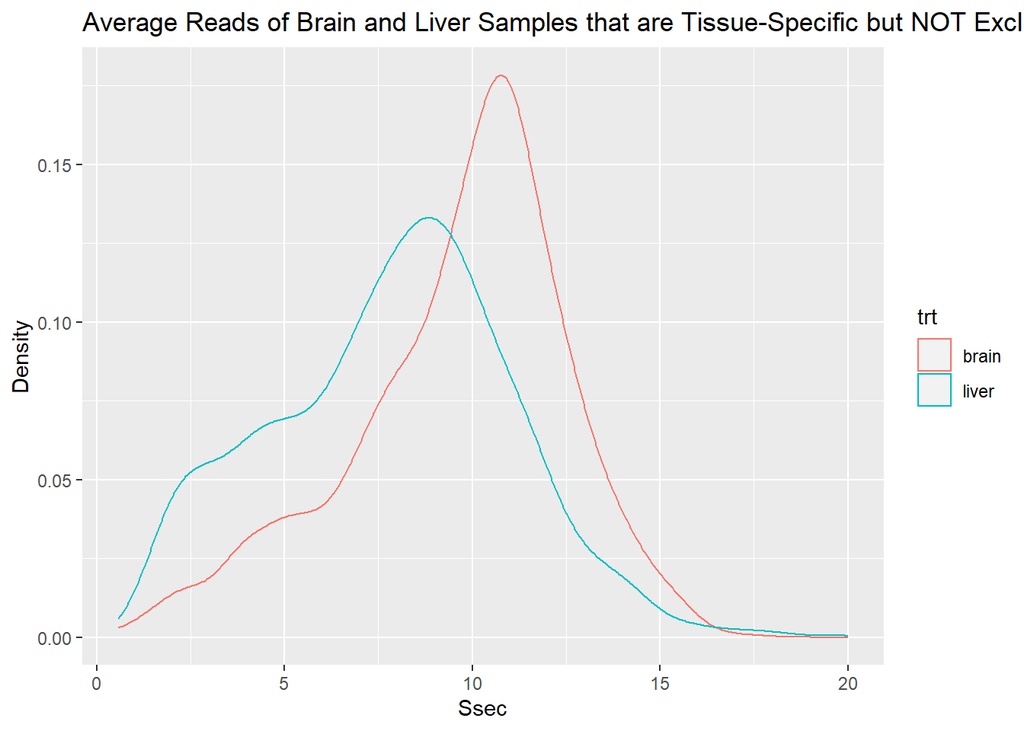

```r
`%!in%` <- Negate(`%in%`)

not_ex_brain = colnames(ts_uni_protein_brain)[colnames(ts_uni_protein_brain) %!in% colnames(ts.ts_uni_protein_brain)]
not_ex_liver = colnames(ts_uni_protein_liver)[colnames(ts_uni_protein_liver) %!in% colnames(ts.ts_uni_protein_liver)]

# checking the reads of the genes in not_ex_brain in brain and liver (i did not code this incorrectly)
not_ex_protein_brain = protein_brain[,colnames(protein_brain) %in% not_ex_brain]
not_ex_protein_liver = protein_liver[,colnames(protein_liver) %in% not_ex_brain]

#sum(colnames(not_ex_protein_brain) != colnames(not_ex_protein_liver))

avg_reads_not_ex_brain = apply(not_ex_protein_brain, 2, mean)
avg_reads_not_ex_liver = apply(not_ex_protein_liver, 2, mean)
label = c(rep("brain", times = length(avg_reads_not_ex_brain)), rep("liver", times = length(avg_reads_not_ex_liver)))
effort = cbind(label, c(avg_reads_not_ex_brain, avg_reads_not_ex_liver))
colnames(effort) = c("trt", "val")
effort = as.data.frame(effort)
effort$trt = factor(effort$trt, levels = c("brain", "liver"))
effort$val = as.numeric(effort$val)

ggplot(effort, aes(val, color = trt)) +
  geom_density() +
  labs(title = "Average Reads of Brain and Liver Samples that are Tissue-Specific but NOT Exclusive to Brain/Liver", x = "Ssec", y = "Density")
```

```r
wil.effort = coin::wilcox_test(val ~ trt, effort)
wil.effort
```

```
##
##  Asymptotic Wilcoxon-Mann-Whitney Test
##
## data:  val by trt (brain, liver)
## Z = 15.105, p-value < 2.2e-16
## alternative hypothesis: true mu is not equal to 0
```

It seems that in the uniprot database, tissue-specicificity does not indicate that a protein is only found in a single tissue, rather that there is SOME KIND of specificity in where it is found.

ENSRNOG00000003732: from top_brain; “Detected in brain (at protein level)” ENSRNOG00000023337: from top_brain; “Expressed in the dorsal root ganglia” ENSRNOG00000018962: from top_brain; “Expressed in the ventricle and atrium of adult rats. Also detected in the lung, kidney, liver, skeletal muscle, stomach and urinary bladder. Not detected in brain, colon, testis, spleen or thymus. Overexpressed in the ventricles in the case of hypertension and hypertrophy.” in the ensembl database, they say there is expression in brain with an expression score of 56.67, compared to 77.93 in the liver

ENSRNOG00000002811: from the Secreted TS Uniprot Exclusive Brain dataset; “Expressed in olfactory bulb, cerebellum and neuronal layers in hippocampus.”

ENSRNOG00000050761: from the Secreted TS Uniprot Exclusive Liver dataset; “Expressed by the liver and secreted in plasma.”

ENSRNOG00000012196: from the Secreted TS Uniprot Liver dataset; “Highly expressed in brain, kidney and heart (PubMed:11328816). Expressed at lower level in other tissues such as liver (PubMed:11328816). Expressed in intestine, kidney and liver (at protein level) (PubMed:11328816, PubMed:11330410). Localizes in the epithelia of the jejunum and ileum (PubMed:11330410).”

ENSRNOG00000020889: not exclusive but tissue specific brain; “Minor constituent of the mineralized matrix of bone. Detected in calvaria, rib cartilage, liver, kidney, spleen, brain, lung, skeletal and heart muscle with highest expression in calvaria and approximately half the amount in kidney, liver and brain.”